# Basic Skills in Visualing Data and Exporatory Data Analysis Using R

## Graphical displays for spread and location for the singers dataset

### Online tutorials

#### YouTube tutorial: Boxplot in R

For a short online YouTube tutorials:

- by Data Science Tutorials, about boxplot using the package see [YTVD8](https://www.youtube.com/watch?v=48UvtcXTb9U).
- by LawrenceStats, about boxplot using the package see [YTVD9](https://www.youtube.com/watch?v=48UvtcXTb9U)

#### Web tutorial: Advanced boxplots in R

Example for advanced boxplots in R using the package and code to produce the plots can be found in the R Graph Gallery website here [WAVD2](https://www.r-graph-gallery.com/boxplot).

### Boxplot for the singers data

A boxplot for the singers’ height by voice group can be produced using the function

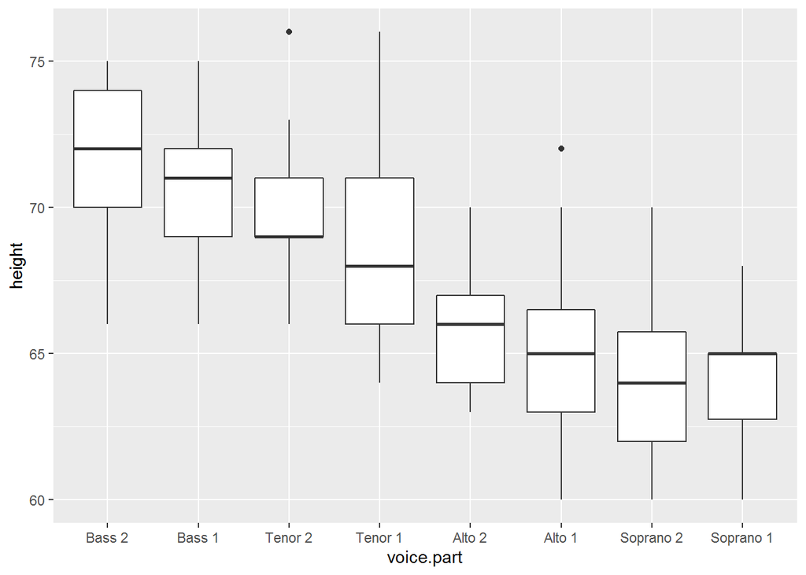

Boxplot for the singers data (I.1).

```r
ggplot(singer, aes(voice.part,height)) + geom_boxplot()
```

Colors (by group) can be added to the boxplot using the argument .

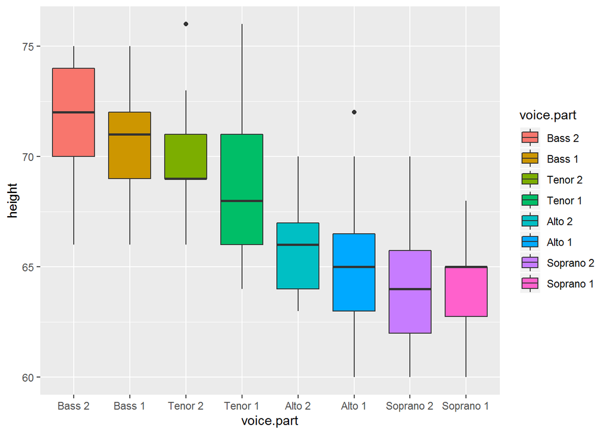

Boxplot for the singers data (I.2).

```r
ggplot(singer, aes(voice.part,height,fill=voice.part)) + geom_boxplot()
```

Data can be added to the boxplot using the argument .

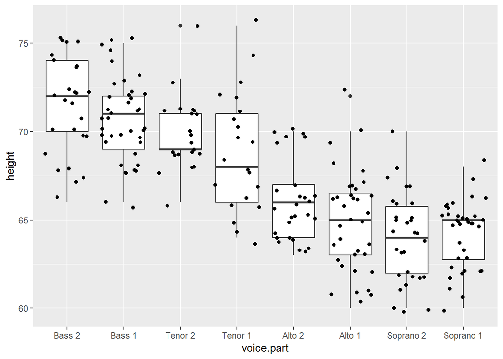

Boxplot for the singers data (II).

```r
qplot(voice.part, height, data = singer, geom = c("boxplot", "jitter"))
```

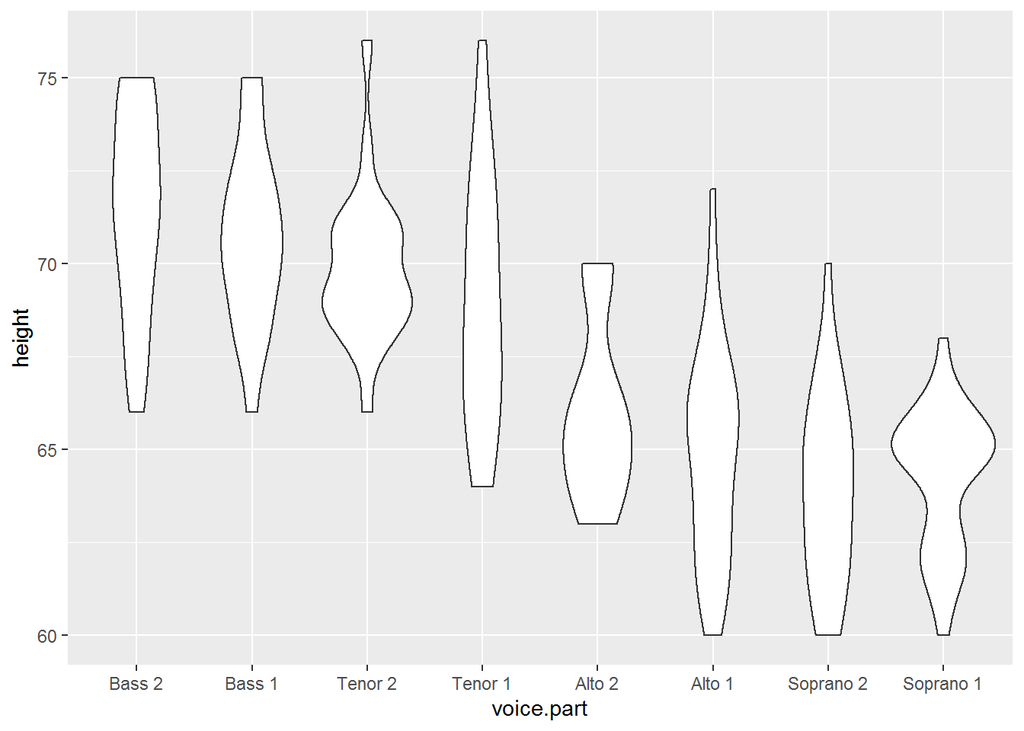

Violin plot for the singers data.

```r
ggplot(singer, aes(voice.part,height)) + geom_violin()
```

## Kareem Abdul Jabbar and Karl Malone’s total number of points

Only four NBA players scored more than 33000 points during their career: Kareem Abdul-Jabbar (KAJ, 38387 points in 1560 games), Karl Malone (KM, 36928, 1476), Kobe Bryant KB, (33643,1346) and LeBron James (LJ, 33313,1228). In the section we compare the distribution of the total number of points between Kareem Abdul-Jabbar and Karl Malone. The data are given in the dataframe.

```r
head(xx1)
```

```
##    PTS PLAYER
## 1 1203     KM
## 2 1779     KM
## 3 2268     KM
## 4 2326     KM
## 5 2540     KM
## 6 2382     KM
```

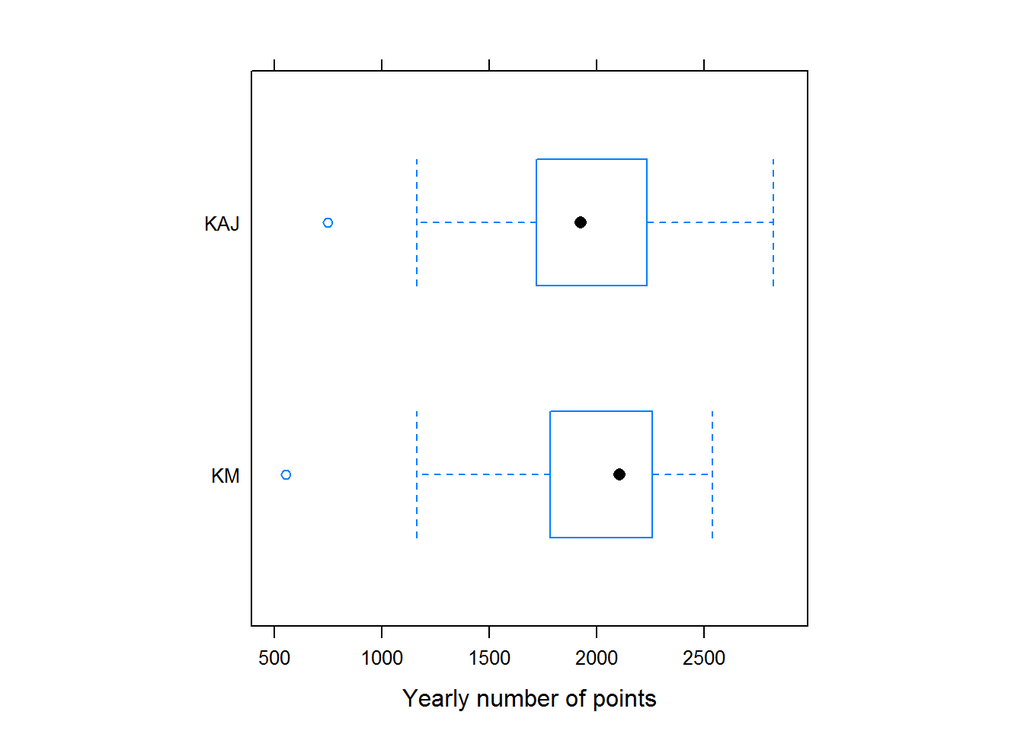

Number of points for Kareem Abdul-Jabbar and Karl Malone.

```r
bwplot(PLAYER~PTS,
                data = xx1,
                layout = c(1, 1),
                aspect = 1,
                xlab = "Yearly number of points")
```

The violin plot is produced using the function .

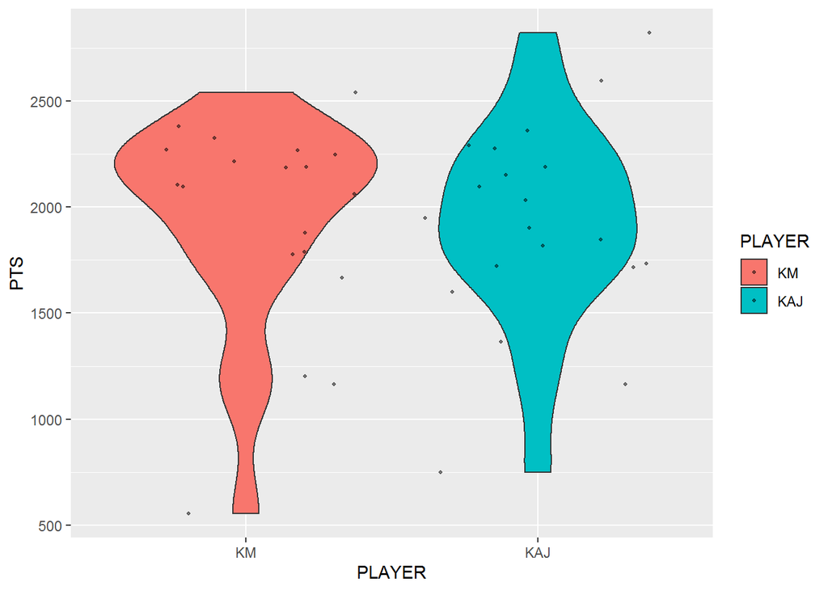

Number of points for Kareem Abdul-Jabbar and Karl Malone.

```r
ggplot(xx1, aes(PLAYER,PTS,fill=PLAYER)) + geom_violin()+geom_jitter(color="black", size=0.75, alpha=0.5)
```

The MAD, equal to 326.17 and 363.97 for KM and KAJ, respectively, and interquartile range, 475 and 491.25 for KM and KAJ, respectively indicate that the variability of KM is slightly lower then the variability of KAJ.

```r
tapply(xx1$PTS,xx1$PLAYER,mad)
```

```
##       KM      KAJ
## 326.1720 363.9783
```

```r
#tapply(xx$PTS,xx$PLAYER,mad)
Qrange.KM<-diff(quantile(xx1$PTS[xx1$PLAYER=="KM"],probs=c(0.25,0.75)))
Qrange.KAJ<-diff(quantile(xx1$PTS[xx1$PLAYER=="KAJ"],probs=c(0.25,0.75)))
Qrange.KM
```

```
## 75%
## 475
```

```r
Qrange.KAJ
```

```
##    75%
## 491.25
```

## The number of 3 points attempt made by the Golden State Warriors: 2010-2019

```r
load("C:\\projects\\NBA\\GSW\\GSW1.RData")
#head(xxx)
#length(xxx$A3P)
#sum(xxx$A3P)
```

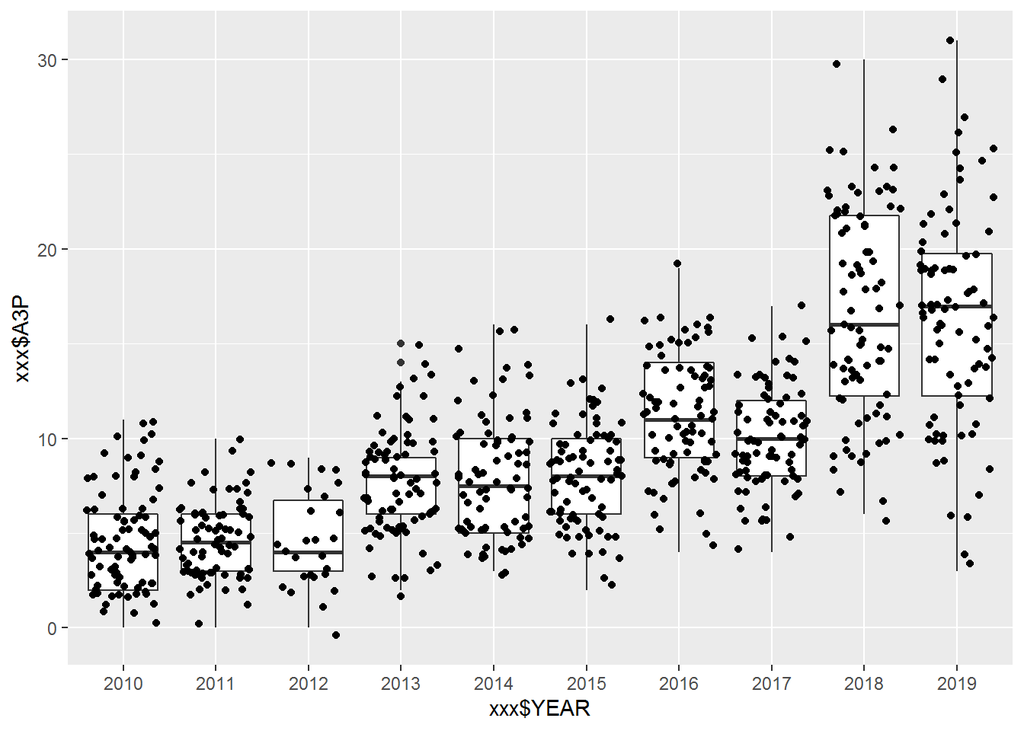

GSW: 3PA per game over time (I).

```r
qplot(xxx$YEAR, xxx$A3P, data = xxx, geom = c("boxplot", "jitter"))
```

The same pattern using a violin plot.

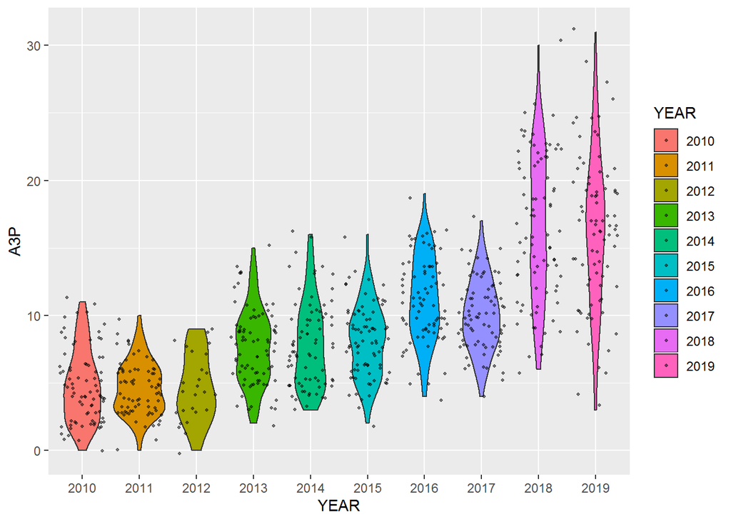

GSW: 3PA per game over time (II).

```r
ggplot(xxx, aes(YEAR,A3P,fill=YEAR)) + geom_violin()+geom_jitter(color="black", size=0.75, alpha=0.5)
```

The same plot with smmothed trend over time.

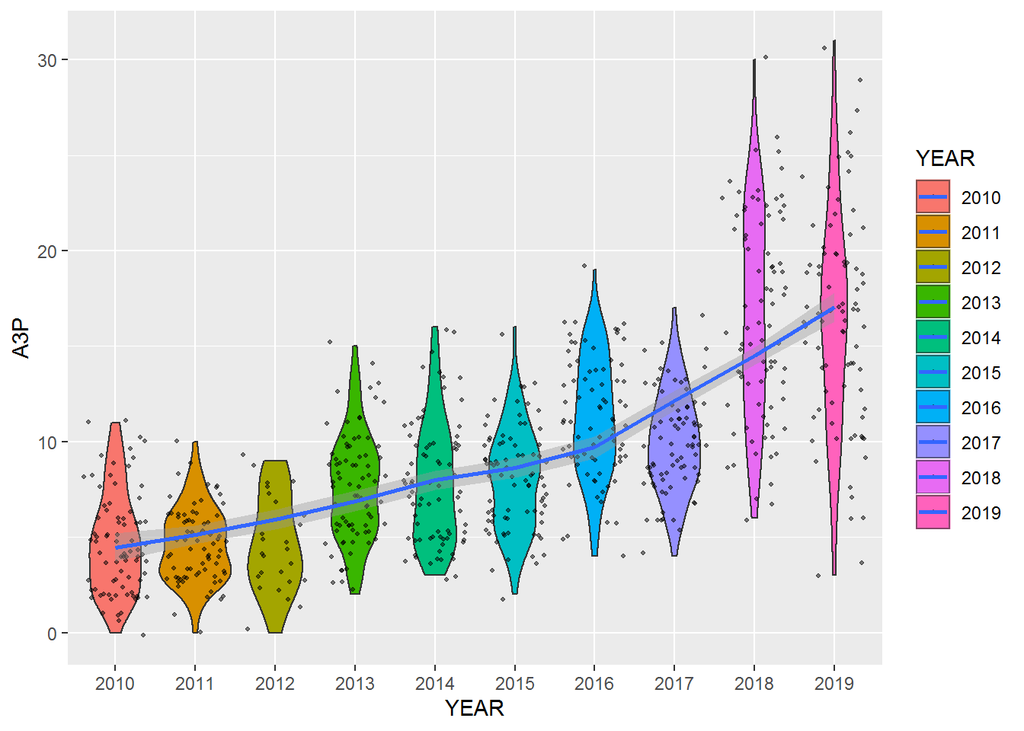

GSW: 3PA per game over time (III).

```r
ggplot(xxx, aes(YEAR,A3P,fill=YEAR)) + geom_violin()+geom_jitter(color="black", size=0.75, alpha=0.5)+
       geom_smooth(aes(group=1))
```

# The quantile plot

## Definitions and examples

### Quantile

Let $X_{(1)},X_{(2)} \dots, X_{(n)}$ be the order statistics. The $f$ quantile of the sample is order statistic $X_{(i)}$ that a proportion $f$ of the observations is less than or equal to. For example, the median is the 0.5 quantile since $50 \%$ of the observations are less than or equal to the median. The lower fourth is the value that $25 \%$ of the observations are less than or equal to, i.e. that the lower forth is the 0.25 quantile of the sample.

### f-value

The $f_{i}$ value is the proportion of observations in the sample that are less than or equal to the $i'th$ order statistic, $X_{(i)}$. Hence,
$$f_{i}=\frac{i}{n}.$$
So $X_{(i)}$ is the $f_{i}$ quantile of the sample.

### Quantile plot

```r
x<-sort(singer$height[singer$voice.part=="Bass 2"])
n<-length(x)
f.value<-c(1:n)/n
cbind(x,f.value)
```

```
##        x    f.value
##  [1,] 66 0.03846154
##  [2,] 67 0.07692308
##  [3,] 67 0.11538462
##  [4,] 68 0.15384615
##  [5,] 68 0.19230769
##  [6,] 69 0.23076923
##  [7,] 70 0.26923077
##  [8,] 70 0.30769231
##  [9,] 70 0.34615385
## [10,] 70 0.38461538
## [11,] 71 0.42307692
## [12,] 72 0.46153846
## [13,] 72 0.50000000
## [14,] 72 0.53846154
## [15,] 72 0.57692308
## [16,] 72 0.61538462
## [17,] 72 0.65384615
## [18,] 72 0.69230769
## [19,] 74 0.73076923
## [20,] 74 0.76923077
## [21,] 74 0.80769231
## [22,] 74 0.84615385
## [23,] 75 0.88461538
## [24,] 75 0.92307692
## [25,] 75 0.96153846
## [26,] 75 1.00000000
```

To produce the quantile plot we use the function with the argument in the following way

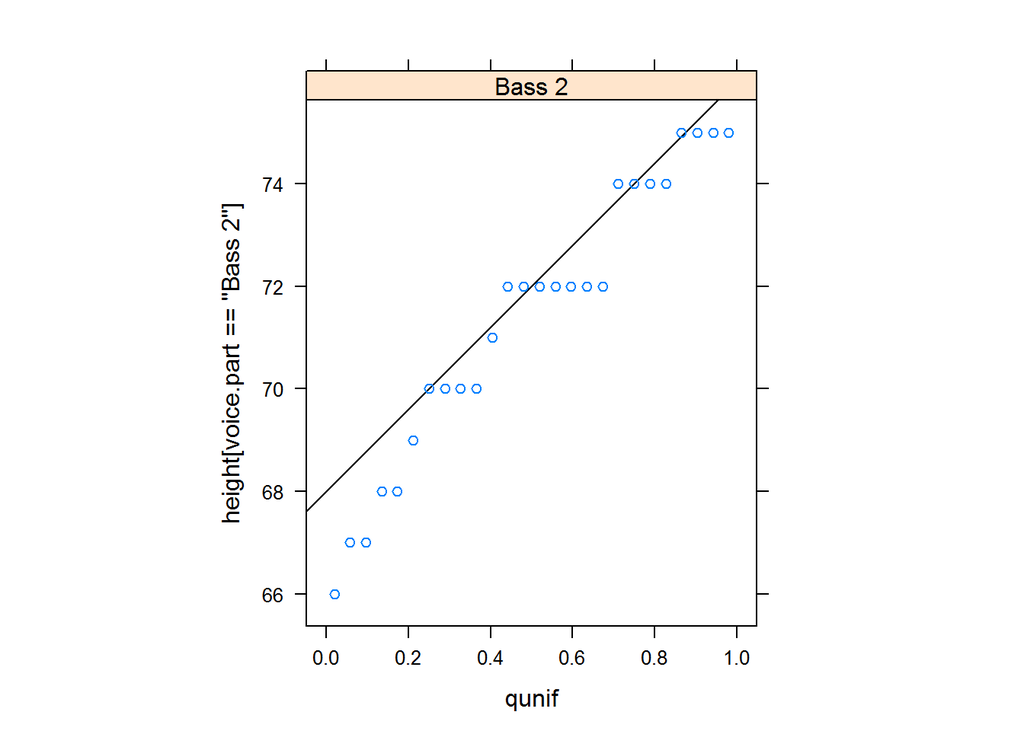

Quantile plot for the second bass group.

```r
qqmath(~ height[voice.part=="Bass 2"] | voice.part[voice.part=="Bass 2"] , aspect = "xy",
       data = singer,layout=c(1,1),distribution = qunif,
       prepanel = prepanel.qqmathline,
       panel = function(x, ...) {
          panel.qqmathline(x, ...)
          panel.qqmath(x, ...)
       })
```

Note that the argument implies that quantile for a uniform distribution will be calculated, i.e, $f_{i}=i / n$. For a quantile plot for all voice groups, we use

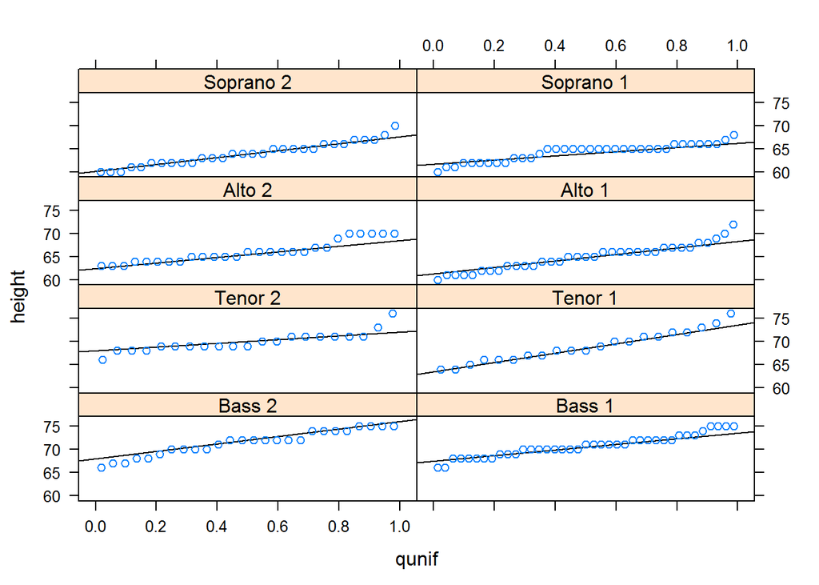

Quantile plot for all voice groups.

```r
qqmath(~ height | voice.part, aspect = 0.25, data = singer,layout=c(2,4),
       distribution = qunif,
       prepanel = prepanel.qqmathline,
       panel = function(x, ...) {
          panel.qqmathline(x, ...)
          panel.qqmath(x, ...)
       })
```

## Comparing distributions with QQ plots

### Example : The chicks dataset

In this section we will discuss ways to compare two (or more) distributions. We will use the chicks dataset as an example. The data contains data from an experiment that was conducted to measure and compare the effectiveness of various feed supplements on the growth rate of chickens.The data set ia avilable as data frame in R (chickwts) and consists two variables: the weight (weight) of the chicken and the diet type (feed). A part of th data is shown below.

```r
head(chickwts)
```

```
##   weight      feed
## 1    179 horsebean
## 2    160 horsebean
## 3    136 horsebean
## 4    227 horsebean
## 5    217 horsebean
## 6    168 horsebean
```

In this sction, we will compare two diet groups: the Sunflower diet and the Linseed diet. The panel below shows that the mean of the Sunflower (328.91) is higher than the mean of the Linseed diet (218.75).

```r
weight.med <- tapply(chickwts$weight,chickwts$feed,median)
weight.mean <- tapply(chickwts$weight,chickwts$feed,mean)
weight.sd <- sqrt(tapply(chickwts$weight,chickwts$feed,var))
chick.n <- tapply(chickwts$weight,chickwts$feed,length)
data.frame(weight.med,weight.mean,weight.sd,chick.n)
```

```
##           weight.med weight.mean weight.sd chick.n
## casein         342.0    323.5833  64.43384      12
## horsebean      151.5    160.2000  38.62584      10
## linseed        221.0    218.7500  52.23570      12
## meatmeal       263.0    276.9091  64.90062      11
## soybean        248.0    246.4286  54.12907      14
## sunflower      328.0    328.9167  48.83638      12
```

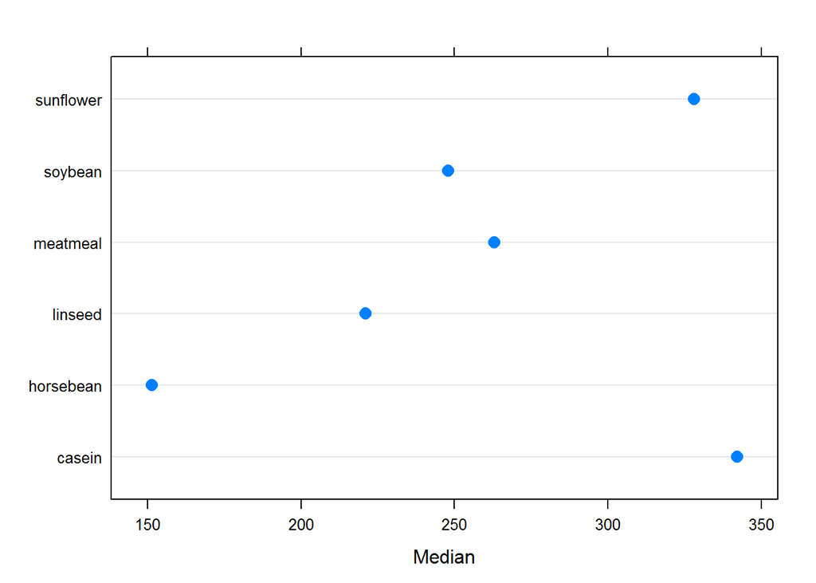

Dotplot for the medians weights.

```r
dotplot(names(weight.med)~weight.med,cex=1.25,xlab="Median")
```

Both the group means and the dotplot rely on the same method to compare the two samples. First, we summarize the distributions with the location estimator (mean or median), and then the comparison between the two diets is based on the summaries. Alternativly, we can use stripplot which presented both the data and summary in the follwoing way

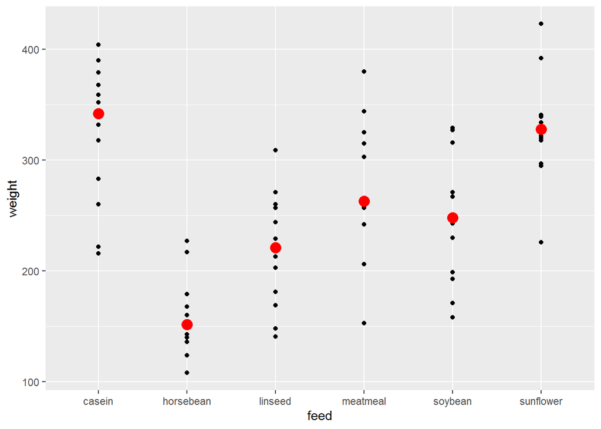

Dotplot by diet grpup.

```r
ggplot(chickwts, aes(feed,weight)) +
geom_point() +
stat_summary(geom = "point", fun.y = "median", colour = "red", size = 4)
```

### The QQ plot

An alternative approach is to compare the quantiles of the two distributions using a quantile-quantile plot (QQ plot). Let $x$ and $y$ be two datasets, $x=(x_{1},x_{2}, \dots ,x_{n})$ and $y=(y_{1},y_{2}, \dots ,y_{m})$. Let $x_{(1)},x_{(2)}, \dots ,x_{(n)}$ be order statiatics for the first dataset and $y_{(1)},y_{(2)}, \dots ,y_{(m)}$ be order statistics for the second dataset. A QQ plot is a figure in which $x_{(i)}$ is plotted against $y_{(i)}$. If $y_{(i)}=x_{(i)}$ for all $i$, then we expect the QQ plot to be a straight line and the quantiles $(x_{(i)},y_{(i)})$ to be on the $45^{o}$ line. If the distribution of the y’s is a of the distribution of the x’s, that is
$$y_{i}=x_{i}+\Delta,$$
then if $\Delta > 0$, we expect that points in the QQ plot will be a straight line above the $45^{o}$ line (and the opposite, of course, for $\Delta < 0$). Let us look at the samples of Sunflower and Linseed diets. We can see from the panel below that for all $i$, $y_{(i)} > x_{(i)}$, that is all the quantiles of the sunflower sample are higher than the corresponding quantiles of the linseed sample.

```r
cbind(sort(chickwts$weight[chickwts$feed=="sunflower"]),
      sort(chickwts$weight[chickwts$feed=="linseed"]))
```

```
##       [,1] [,2]
##  [1,]  226  141
##  [2,]  295  148
##  [3,]  297  169
##  [4,]  318  181
##  [5,]  320  203
##  [6,]  322  213
##  [7,]  334  229
##  [8,]  339  244
##  [9,]  340  257
## [10,]  341  260
## [11,]  392  271
## [12,]  423  309
```

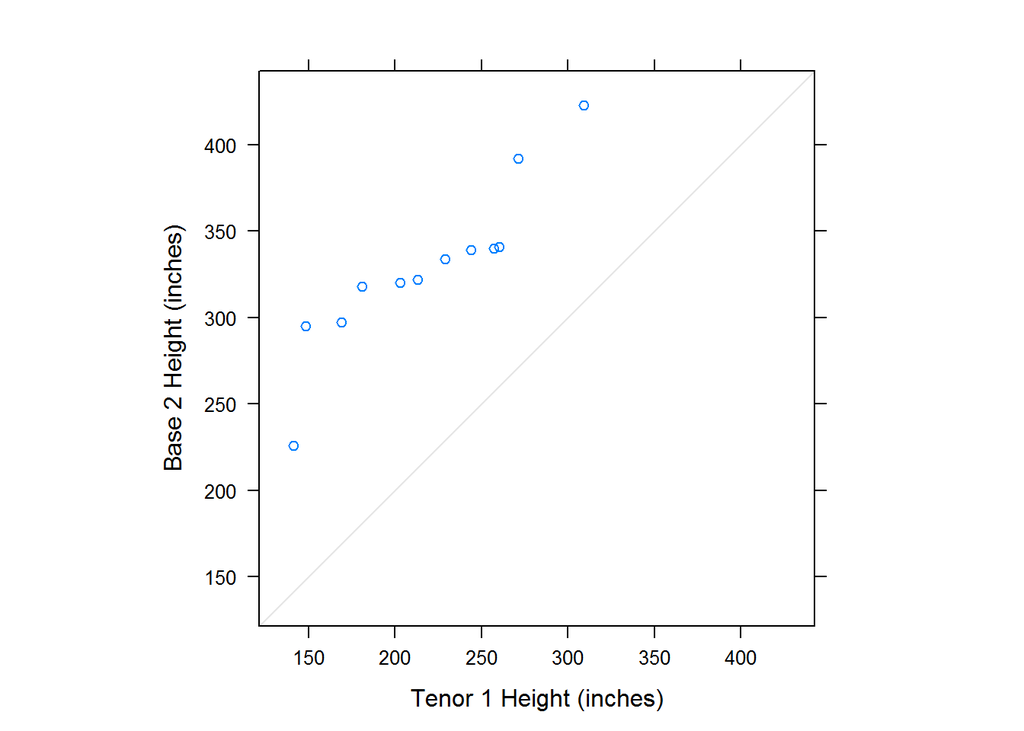

qqplot between the sunflower and the linseed groups.

```r
qq(chickwts$feed ~ chickwts$weight,data=chickwts,
        subset=chickwts$feed=="sunflower" | chickwts$feed=="linseed",
        aspect=1,
        xlab = "Tenor 1 Height (inches)",
        ylab = "Base 2 Height (inches)")
```

### Example : The singer dataset

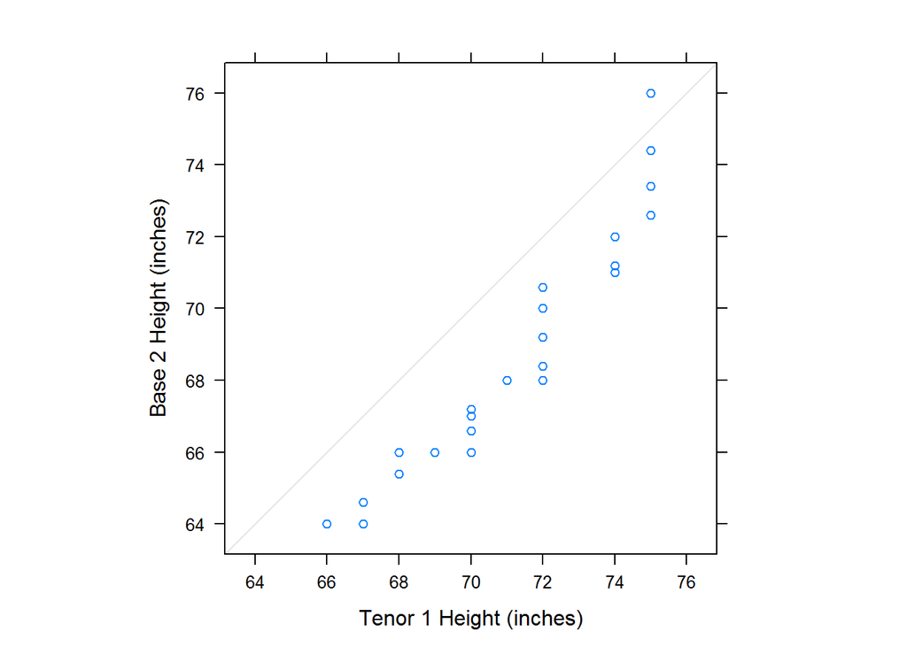

qqplot between the second bass and first tenor groups.

```r
qq(singer$voice.part ~ singer$height,data=singer,
        subset=voice.part=="Bass 2" | voice.part=="Tenor 1",
        aspect=1,
        xlab = "Tenor 1 Height (inches)",
        ylab = "Base 2 Height (inches)")
```

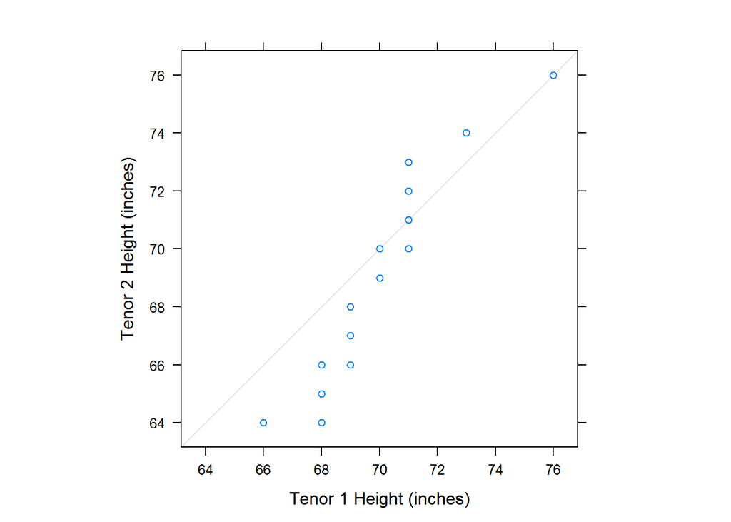

qqplot between the two tenor groups.

```r
qq(singer$voice.part ~ singer$height,data=singer,
        subset=voice.part=="Tenor 2" | voice.part=="Tenor 1",
        aspect=1,
        xlab = "Tenor 1 Height (inches)",
        ylab = "Tenor 2 Height (inches)")
```